# Cross-Validation

Alan Arnholt

Last Updated on: Mar 23, 2017 at 14:14:15

# 1 Cross-Validation Handout

*Note: Working definitions and graphs are taken from Ugarte, Militino, and Arnholt (2016)*

## 1.1 The Validation Set Approach

The basic idea behind the validation set approach is to split the available data into a training set and a testing set. A regression model is developed using only the training set. Consider Figure 1.1 which illustrates a split of the available data into a training set and a testing set.

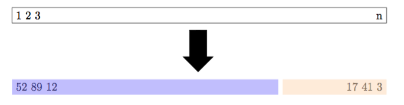

Figure 1.1: Validation set approach

The percent of values that are allocated into training and testing may vary based on the size of the available data. It is not unusual to allocate 70–75% of the available data as the training set and the remaining 25–30% as the testing set. The predictive performance of a regression model is assessed using the testing set. One of the more common methods to assess the predictive performance of a regression model is the mean square prediction error (MSPE). The MSPE is defined as

$$\begin{equation}
\textrm{MSPE} = \frac{1}{n}\sum_{i=1}^{n}(y_i - \hat{y}_i)^2
\tag{1.1}
\end{equation}$$

## 1.2 Leave-One-Out Cross Validation

The leave-one-out cross-validation (LOOCV) eliminates the problem of variability in MSPE present in the validation set approach. The LOOCV is similar to the validation set approach as the available $n$ observations are split into training and testing sets. The difference is that each of the available $n$ observations are split into $n$ training and $n$ testing sets where each of the $n$ training sets consist of $n - 1$ observations and each of the testing sets consists of a single different value from the original $n$ observations. Figure 1.2 provides a schematic display of the leave-one-out cross-validation process with testing sets (light shade) and training sets (dark shade) for a data set of $n$ observations.

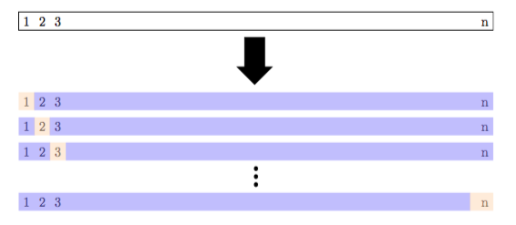

Figure 1.2: Leave-one-out cross validation

The MSPE is computed with each testing set resulting in $n$ values of MSPE. The LOOCV estimate for the test MSPE is the average of these $n$ MSPE values denoted as

$$\begin{equation}
\textrm{CV}_{(n)} = \frac{1}{n}\sum_{i=1}^{n}\textrm{MSPE}_i
\tag{1.2}
\end{equation}$$

## 1.3 $k$-Fold Cross Validation

$k$-fold cross-validation is similar to LOOCV in that the available data is split into training sets and testing sets; however, instead of creating $n$ different training and testing sets, $k$ folds/groups of training and testing sets are created where $k < n$ and each fold consists of roughly $n/k$ values in the testing set and $1 - n/k$ values in the training set. Figure 1.3 shows a schematic display of 5-fold cross-validation. The lightly shaded rectangles are the testing sets and the darker shaded rectangles are the training sets.

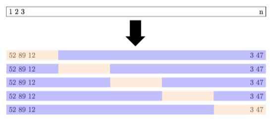

Figure 1.3: Five fold cross-validation

The MSPE is computed on each of the $k$ folds using the testing set to evaluate the regression model built from the training set. The weighted average of $k$ MSPE values is denoted as

$$\begin{equation}
\textrm{CV}_{(k)} = \sum_{k=1}^{k}\frac{n_k}{n}\textrm{MSPE}_k
\tag{1.3}
\end{equation}$$

Note that LOOCV is a special case of $k$-fold cross-validation where $k$ is set equal to $n$. An important advantage $k$-fold cross-validation has over LOOCV is that $\textrm{CV}_{k}$ for $k = 5$ or $k = 10$ provides a more accurate estimate of the test error rate than does $\textrm{CV}_n$.

## 1.4 Creating some data

```r
set.seed(357)
n <- 1000           # Number of observations to generate
SD <- 0.5
xs <- sort(runif(n, 5, 9))
ys <- sin(xs) + rnorm(n, 0, SD)
DF <- data.frame(x = xs, y = ys)
rm(xs, ys)
library(DT)
datatable(DF)
```

|  | x | y |
| --- | --- | --- |
| 1 | 5.00218567345291 | -0.461998687888378 |
| 2 | 5.00949552096426 | -1.2552623009749 |
| 3 | 5.01820665318519 | -0.350569477015049 |
| 4 | 5.02762991003692 | -1.06623235222228 |
| 5 | 5.03651614766568 | -0.0221593456286351 |
| 6 | 5.03874948713928 | -1.7631689843736 |
| 7 | 5.04254586063325 | -0.769226533846735 |
| 8 | 5.04476176574826 | -1.55118888999942 |
| 9 | 5.04479634109885 | -1.19827408822592 |
| 10 | 5.05191567540169 | -0.278206209088567 |

[output cut: 990 more lines]

## 1.5 Validation Set Approach

- Create a training set using 75% of the observations in `DF`.
- Sort the observations in the training and testing sets.

```r
n <- nrow(DF)
train <- sample(n, floor(0.75 * n), replace = FALSE)
trainSET <- DF[train, ]
trainSET <- trainSET[order(trainSET$x), ]
testSET <- DF[-train, ]
testSET <- testSET[order(testSET$x), ]
dim(trainSET)
```

```
[1] 750   2
```

```r
dim(testSET)
```

```
[1] 250   2
```

- Fit a quadratic model using the training set (`trainSET`).

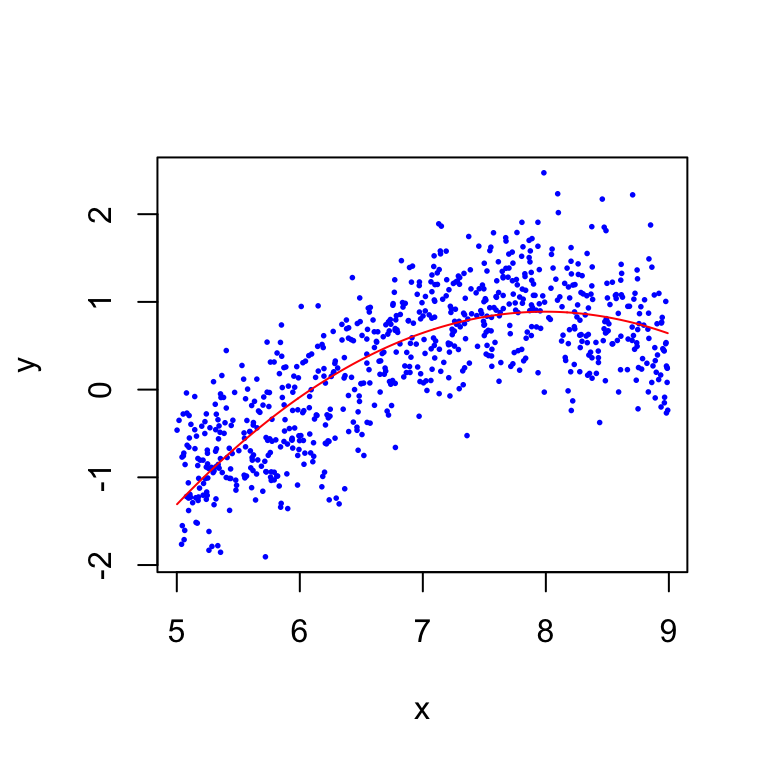

```r
library(ggplot2)
# Base R
plot(y ~ x, data = trainSET, pch = 19, cex = .25, col = "blue")
modq <- lm(y ~ poly(x, 2, raw = TRUE), data = trainSET)
yhat <- predict(modq, data = trainSET)
lines(trainSET$x, yhat, col = "red")
```

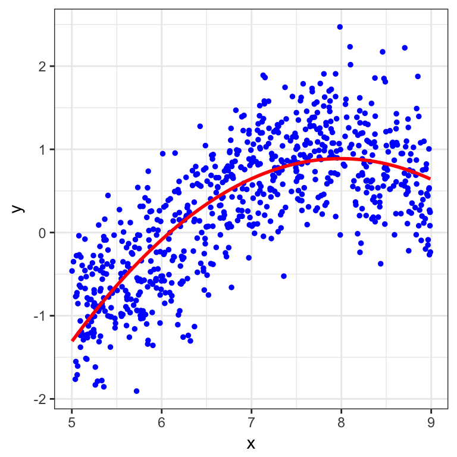

```r
# ggplot2 approach
ggplot(data = trainSET, aes(x = x, y = y)) +
  geom_point(color = "blue", size = 1) +
  theme_bw() +
  geom_smooth(method = "lm", formula = y ~ poly(x, 2, raw = TRUE), color = "red", se = FALSE)
```

```r
# Summary of quadratic model
summary(modq)
```

```
Call:
lm(formula = y ~ poly(x, 2, raw = TRUE), data = trainSET)

Residuals:
     Min       1Q   Median       3Q      Max
-1.52749 -0.37416  0.01064  0.35288  1.58342

Coefficients:
                         Estimate Std. Error t value Pr(>|t|)
(Intercept)             -14.79458    0.73481  -20.13   <2e-16 ***
poly(x, 2, raw = TRUE)1   3.92468    0.21463   18.29   <2e-16 ***
poly(x, 2, raw = TRUE)2  -0.24554    0.01534  -16.01   <2e-16 ***
---
Signif. codes:  0 '***' 0.001 '**' 0.01 '*' 0.05 '.' 0.1 ' ' 1

Residual standard error: 0.509 on 747 degrees of freedom
Multiple R-squared:  0.6202,    Adjusted R-squared:  0.6192
F-statistic: 609.9 on 2 and 747 DF,  p-value: < 2.2e-16
```

## 1.6 Compute the training `MSPE`

```r
MSPE <- mean(resid(modq)^2)
MSPE
```

```
[1] 0.258064
```

## 1.7 Compute the testing `MSPE`

```r
yhtest <- predict(modq, newdata = testSET)
MSPEtest <- mean((testSET$y - yhtest)^2)
MSPEtest
```

```
[1] 0.2861634
```

## 1.8 Fit a cubic model.

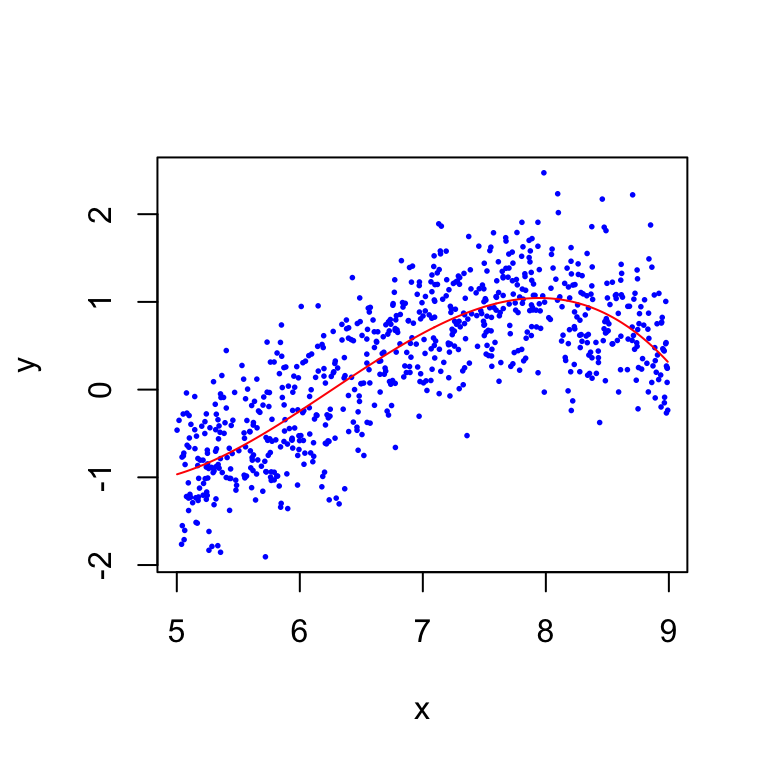

```r
# Base R
plot(y ~ x, data = trainSET, pch = 19, cex = .25, col = "blue")
modc <- lm(y ~ poly(x, 3, raw = TRUE), data = trainSET)
yhat <- predict(modc, data = trainSET)
lines(trainSET$x, yhat, col = "red")
```

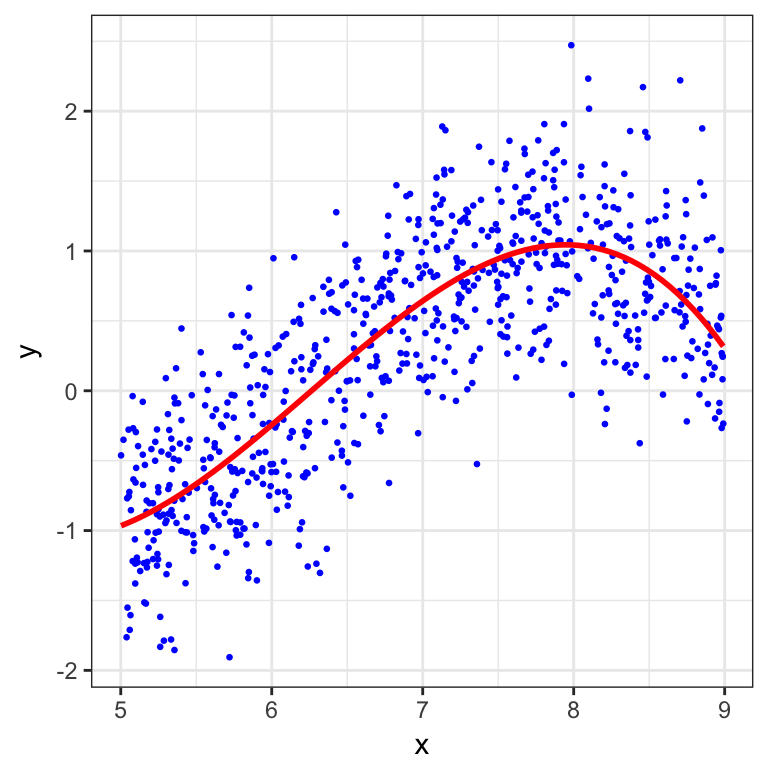

```r
# ggplot2 approach
ggplot(data = trainSET, aes(x = x, y = y)) +
  geom_point(color = "blue", size = 0.5) +
  theme_bw() +
  geom_smooth(method = "lm", formula = y ~ poly(x, 3, raw = TRUE), color = "red", se = FALSE)
```

```r
# Summary of cubic model
summary(modc)
```

```
Call:
lm(formula = y ~ poly(x, 3, raw = TRUE), data = trainSET)

Residuals:
     Min       1Q   Median       3Q      Max
-1.41528 -0.34058 -0.02531  0.35033  1.54259

Coefficients:
                         Estimate Std. Error t value Pr(>|t|)
(Intercept)              20.71698    4.86274   4.260 2.30e-05 ***
poly(x, 3, raw = TRUE)1 -11.81201    2.14187  -5.515 4.82e-08 ***
poly(x, 3, raw = TRUE)2   2.03837    0.30975   6.581 8.82e-11 ***
poly(x, 3, raw = TRUE)3  -0.10866    0.01472  -7.382 4.18e-13 ***
---
Signif. codes:  0 '***' 0.001 '**' 0.01 '*' 0.05 '.' 0.1 ' ' 1

Residual standard error: 0.4917 on 746 degrees of freedom
Multiple R-squared:  0.646, Adjusted R-squared:  0.6446
F-statistic: 453.9 on 3 and 746 DF,  p-value: < 2.2e-16
```

## 1.9 Compute the training `MSPE`

```r
MSPE <- mean(resid(modc)^2)
MSPE
```

```
[1] 0.2404968
```

## 1.10 Compute the testing `MSPE`

```r
yhtest <- predict(modc, newdata = testSET)
MSPEtest <- mean((testSET$y - yhtest)^2)
MSPEtest
```

```
[1] 0.2720598
```

## 1.11 Your Turn

- Create a training set (80%) and testing set (20%) of the observations from the data frame `HSWRESTLER` from the `PASWR2` package. Store the results from regressing `hwfat` onto `abs` and `triceps` in the object `modf`.
- Compute the test `MSPE`.
- Note how the answers of your classmates are all different. The validation estimate of the test MSPE can be highly variable.

```r
# Your Code Here
#
#
#
#
#
#
#
#
#
#
```

## 1.12 Your Turn

The left side of Figure 5.2 on page 178 of James et al. (2013) shows the validation approach used on the `Auto` data set in order to estimate the test error that results from predicting `mpg` using polynomial functions of `horsepower` for one particular split of the original data. The code below creates a similar graph.

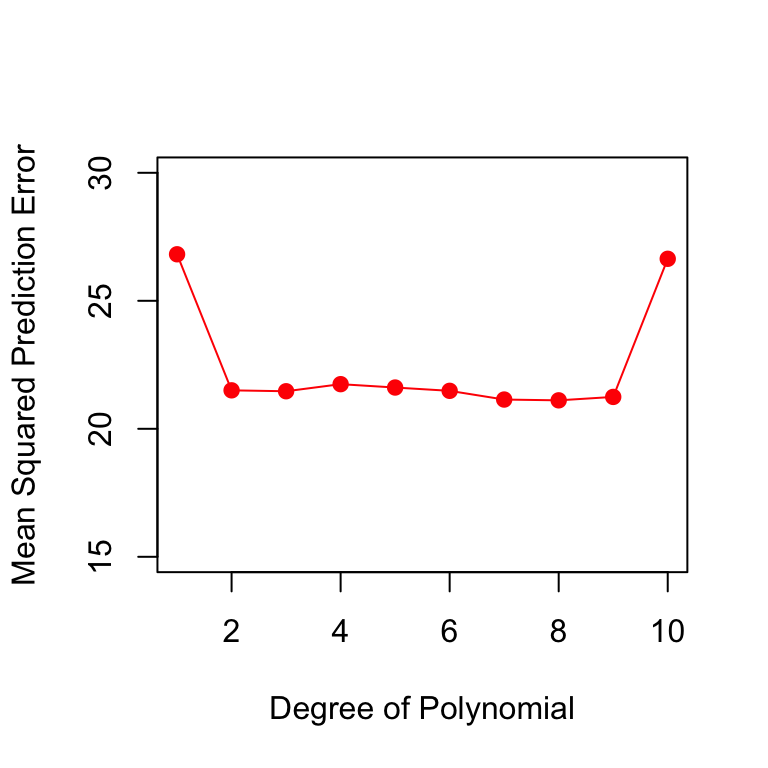

```r
library(ISLR)
n <- nrow(Auto)
plot(1:10, type ="n", xlab = "Degree of Polynomial", ylim = c(15, 30),
     ylab = "Mean Squared Prediction Error")
IND <- sample(1:n, size = floor(n/2), replace = FALSE)
train <- Auto[IND, ]
test <- Auto[-IND, ]
for(i in 1:10){
    mod <- lm(mpg ~ poly(horsepower, i), data = train)
    pred <- predict(mod, newdata = test)
    MSPE[i] <- mean((test$mpg - pred)^2)
  }
lines(1:10, MSPE, col = "red")
points(1:10, MSPE, col = "red", pch = 19)
```

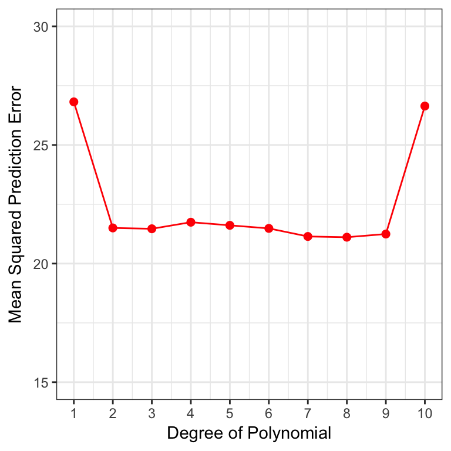

```r
# ggplot2 approach
DF2 <- data.frame(x = 1:10, MSPE = MSPE)
ggplot(data = DF2, aes(x = x, y = MSPE)) +
  geom_point(color = "red", size = 2) +
  geom_line(color = "red") +
  theme_bw() +
  ylim(15, 30) +
  scale_x_continuous(breaks = 1:10) +
  labs(x = "Degree of Polynomial", y = "Mean Squared Prediction Error")
```

- Modify the code above to recreate a graph similar to the right side of Figure 5.2 on page 178 of James et al. (2013). Hint: Place a `for` loop before `IND`.

```r
# Your Code Here
#
#
#
#
#
#
#
#
#
#
#
#
#
#
#
```

## 1.13 $k$ Fold Cross Validation

- Create $k = 5$ folds.
- Compute the $\textrm{CV}_{k=5}$ for `modq`.

```r
set.seed(1)
k <- 5
MSPE <- numeric(k)
folds <- sample(x = 1:k, size = nrow(DF), replace = TRUE)
xtabs(~folds)
```

```
folds
  1   2   3   4   5
200 205 201 196 198
```

```r
sum(xtabs(~folds))
```

```
[1] 1000
```

```r
for(j in 1:k){
  modq <- lm(y ~ poly(x, 2, raw = TRUE), data = DF[folds != j, ])
  pred <- predict(modq, newdata = DF[folds ==j, ])
  MSPE[j] <- mean((DF[folds == j, ]$y - pred)^2)
}
MSPE
```

```
[1] 0.2604303 0.2601093 0.2656551 0.2614124 0.2873636
```

```r
weighted.mean(MSPE, table(folds)/sum(folds))
```

```
[1] 0.26694
```

## 1.14 Your Turn

- Compute the $\textrm{CV}_8$ for `modf`. Recall that `modf` was created from regressing `hwfat` onto `abs` and `triceps`.

```r
# Your Code Here
#
#
#
#
#
#
#
#
#
#
#
#
```

## 1.15 Using `cv.glm` from `boot`

```r
set.seed(1)
library(boot)
glm.fit <- glm(y ~ poly(x, 2, raw = TRUE), data = DF)
cv.err <- cv.glm(data = DF, glmfit = glm.fit, K = 5)$delta[1]
cv.err
```

```
[1] 0.2663178
```

## 1.16 Your Turn

- Compute $\textrm{CV}_8$ for `modf` using `cv.glm`. Recall that `modf` was created from regressing `hwfat` onto `abs` and `triceps`.

```r
# Your Code Here
#
#
#
```

## 1.17 Your Turn

The right side of Figure 5.4 on page 180 of James et al. (2013) shows the 10-fold cross-validation approach used on the `Auto` data set in order to estimate the test error that results from predicting `mpg` using polynomial functions of `horsepower` run nine separate times. The code below creates a graph showing one particular run.

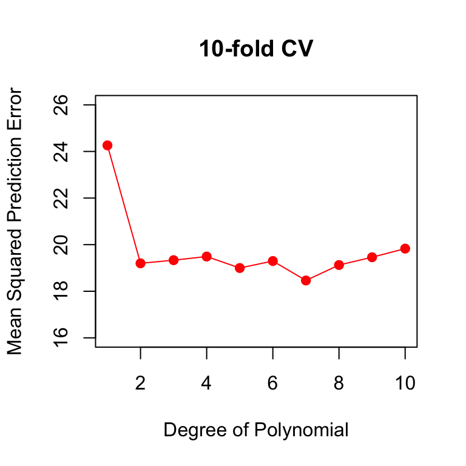

```r
plot(1:10, type ="n", xlab = "Degree of Polynomial", ylim = c(16, 26),
     ylab = "Mean Squared Prediction Error", main = "10-fold CV")
k <- 10 # number of folds
MSPE <- numeric(k)
cv <- numeric(k)
  for(i in 1:10){
    folds <- sample(x = 1:k, size = nrow(Auto), replace = TRUE)
    for(j in 1:k){
      mod <- lm(mpg ~ poly(horsepower, i, raw = TRUE), data = Auto[folds != j, ])
      pred <- predict(mod, newdata = Auto[folds ==j, ])
      MSPE[j] <- mean((Auto[folds == j, ]$mpg - pred)^2)
    }
    cv[i] <- weighted.mean(MSPE, table(folds)/sum(folds))
  }
  lines(1:10, cv, col = "red")
  points(1:10, cv, col = "red", pch = 19)
```

- Use a `for` loop to run the above code nine times. The result should look similar to the right side of Figure 5.4 on page 180 of James et al. (2013).

```r
# Your Code Here
#
#
#
#
#
#
#
#
#
#
#
#
#
#
#
#
#
#
```

- Use the function `cv.glm` to create similar a graph to the right side of Figure 5.4 on page 180 of James et al. (2013).

```r
# Your Code Here
#
#
#
#
#
#
#
#
#
#
```

## 1.18 Leave-One-Out Cross-Validation

```r
set.seed(1)
k <- nrow(DF)
MSPE <- numeric(k)
folds <- sample(x = 1:k, size = nrow(DF), replace = FALSE)
# Note that replace changes to FALSE for LOOCV...can you explain why?
for(j in 1:k){
  modq <- lm(y ~ poly(x, 2, raw = TRUE), data = DF[folds != j, ])
  pred <- predict(modq, newdata = DF[folds ==j, ])
  MSPE[j] <- mean((DF[folds == j, ]$y - pred)^2)
}
mean(MSPE)
```

```
[1] 0.2663587
```

## 1.19 Your Turn

- Compute $\textrm{CV}_n$ for `modf`. Recall that `modf` was created from regressing `hwfat` onto `abs` and `triceps`.

```r
# Your Code Here
#
#
#
#
#
#
#
#
#
```

Recall

$$CV_{n}=\frac{1}{n}\sum_{i=1}^n\left(\frac{y_i - \hat{y_i}}{1 - h_i}\right)^2$$

```r
modq <- lm(y ~ poly(x, 2, raw = TRUE), data = DF)
h <- hatvalues(modq)
CVn <- mean(((DF$y - predict(modq))/(1 - h))^2)
CVn
```

```
[1] 0.2663587
```

## 1.20 Your Turn

- Compute $\textrm{CV}_n$ for `modf` using the mathematical shortcut. Recall that `modf` was created from regressing `hwfat` onto `abs` and `triceps`.

```r
# Your Code Here
#
#
#
```

## 1.21 Using `cv.glm` from `boot`

- Note: If one does not use the `K` argument for the number of folds, `gv.glm` will compute LOOCV.

```r
library(boot)
glm.fit <- glm(y ~ poly(x, 2, raw = TRUE), data = DF)
cv.err <- cv.glm(data = DF, glmfit = glm.fit)$delta[1]
cv.err
```

```
[1] 0.2663587
```

## 1.22 Your Turn

- Compute $\textrm{CV}_n$ for `modf` using `cv.glm`. Recall that `modf` was created from regressing `hwfat` onto `abs` and `triceps`.

```r
# Your Code Here
#
#
#
```

## 1.23 Your Turn

- Create a graph similar to the left side of Figure 5.4 on page 180 of James et al. (2013).

```r
# Your Code Here
#
#
#
#
#
#
#
#
#
#
#
#
#
#
#
```

Using the short cut formula:

```r
# Your Code Here
#
#
#
#
#
#
#
#
#
```

## References

James, Gareth, Daniela Witten, Trevor Hastie, and Robert Tibshirani, eds. 2013. *An Introduction to Statistical Learning: With Applications in R*. Springer Texts in Statistics 103. New York: Springer.

Ugarte, María Dolores, Ana F. Militino, and Alan T. Arnholt. 2016. *Probability and Statistics with R*. Second edition. Boca Raton: CRC Press, Taylor & Francis Group.